# Homofobia w zagrożeniu męskości

Jakub Jędrusiak

2022-04-22 19:16:48

# 1 Legenda

# 2 Opis próby badanej

## 2.1 Liczba osób badanych

**Uwaga:** liczba dotyczy wyłącznie osób, których odpowiedzi zostały uwzględnione w analizie. Z analizy wykluczono ankiety, których czas wypełnienia wyniósł mniej niż 240 sekund(y). Liczba osób wykluczonych na podstawie czasu wypełniania wyniosła 3 (1 w grupie kontrolnej i 2 w grupie eksperymentalnej).

96  
osoby badane łącznie

41  
grupa kontrolna

55  
grupa eksperymentalna

*p* = 0.153  
test *χ*<sup>2</sup> równoliczności grup

```r
# test chi-kwadrat równoliczności grup
rownolicznosc_chi_kwadrat
```

```
## # A tibble: 1 × 6
##       n statistic     p    df method          p.signif
## * <int>     <dbl> <dbl> <dbl> <chr>           <chr>
## 1    96      2.04 0.153     1 Chi-square test ns
```

## 2.2 Wiek

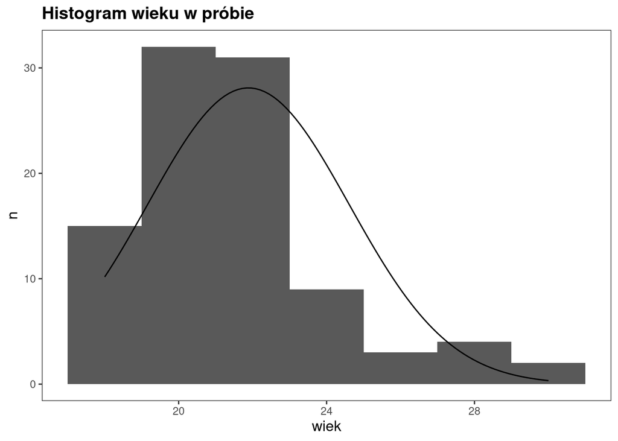

21.89  
Średnia wieku

2.73  
Odchylenie standardowe

22  
Mediana wieku

## 2.3 Wykształcenie

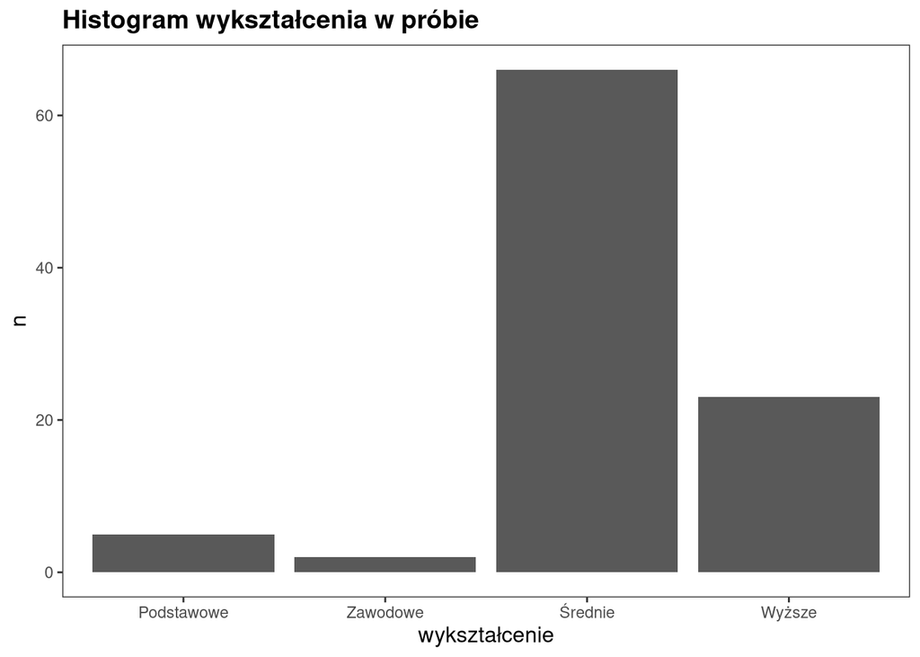

# 3 Statystyki opisowe zmiennych

## 3.1 Cała próba

| Zmienna | N | M | SD | Me | skośność | kurtoza |
| --- | --- | --- | --- | --- | --- | --- |
| NM | 96 | 105.635 | 44.005 | 96.5 | 0.730 | -0.249 |
| HF | 96 | 25.823 | 12.097 | 22.5 | 0.708 | -0.115 |
| HF_geje | 96 | 12.896 | 6.509 | 11.0 | 0.846 | 0.084 |
| HF_lesbijki | 96 | 12.927 | 6.340 | 11.0 | 0.750 | -0.146 |
| wiek | 96 | 21.885 | 2.726 | 22.0 | 1.070 | 1.194 |

## 3.2 Grupa kontrolna

| Zmienna | N | M | SD | Me | skośność | kurtoza |
| --- | --- | --- | --- | --- | --- | --- |
| NM | 41 | 92.878 | 37.671 | 87 | 1.100 | 1.099 |
| HF | 41 | 24.390 | 13.069 | 21 | 0.913 | 0.131 |
| HF_geje | 41 | 11.976 | 6.646 | 10 | 1.026 | 0.390 |
| HF_lesbijki | 41 | 12.415 | 6.760 | 11 | 0.844 | -0.187 |
| wiek | 41 | 21.732 | 2.356 | 21 | 0.930 | 0.973 |

## 3.3 Grupa eksperymentalna

| Zmienna | N | M | SD | Me | skośność | kurtoza |
| --- | --- | --- | --- | --- | --- | --- |
| NM | 55 | 115.145 | 46.258 | 113 | 0.454 | -0.772 |
| HF | 55 | 26.891 | 11.323 | 24 | 0.552 | -0.407 |
| HF_geje | 55 | 13.582 | 6.379 | 12 | 0.729 | -0.124 |
| HF_lesbijki | 55 | 13.309 | 6.043 | 11 | 0.677 | -0.182 |
| wiek | 55 | 22.000 | 2.988 | 22 | 1.035 | 0.821 |

# 4 Testy normalności

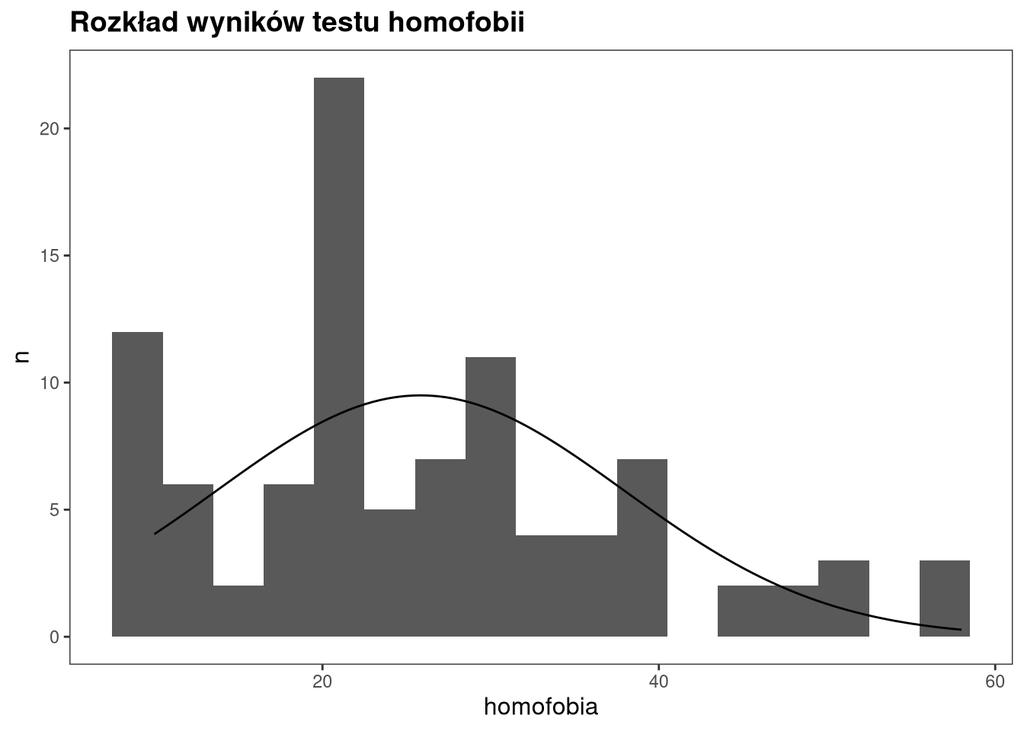

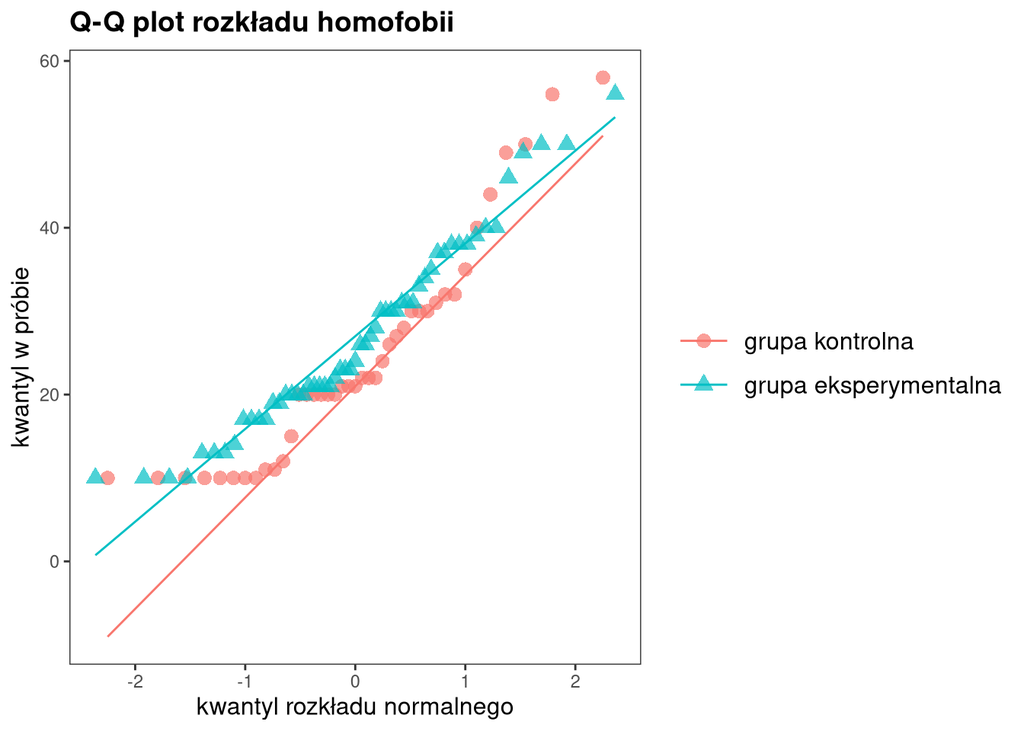

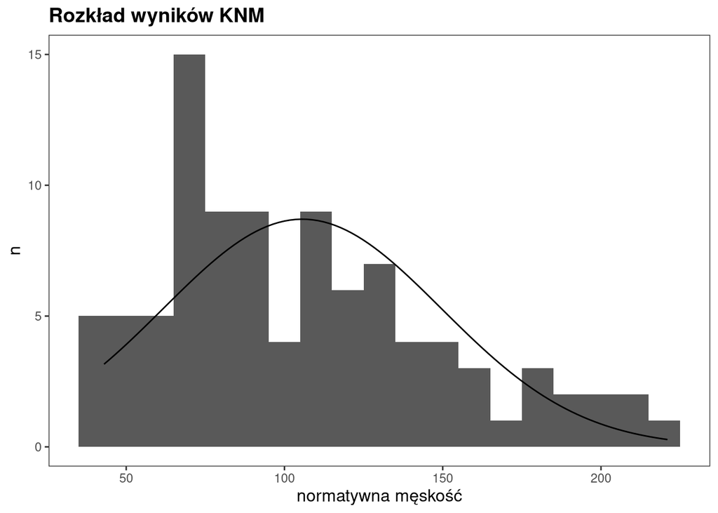

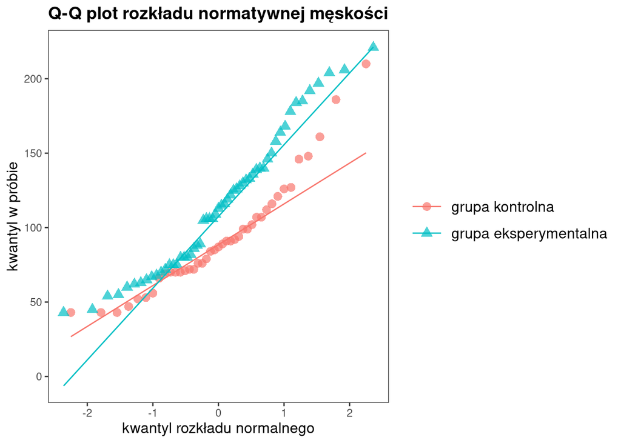

```r
# zastosowano test W Shapiro-Wilka
# grupa kontrolna
SW_kontr
```

```
## # A tibble: 2 × 3
##   variable statistic        p
##   <chr>        <dbl>    <dbl>
## 1 HF           0.888 0.000755
## 2 NM           0.914 0.00426
```

```r
# grupa eksperymentalna
SW_eksp
```

```
## # A tibble: 2 × 3
##   variable statistic      p
##   <chr>        <dbl>  <dbl>
## 1 HF           0.955 0.0368
## 2 NM           0.954 0.0356
```

# 5 Rzetelność testu homofobii

**Uwaga:** nie jestem pewny, czy można policzyć współczynnik alfa z tych danych oraz czy można włączyć do obliczeń wyniki z grupy eksperymentalnej. Tutaj włączyłem dane z obu warunków, ale dla samej kontrolnej wychodzi podobna.

*α* = 0.96  
homofobia wobec gejów

*α* = 0.96  
homofobia wobec lesbijek

```r
# alfa Cronbacha dla homofobii wobec gejów
alfa_geje
```

```
##
## Reliability analysis  homofobia wobec gejów
## Call: alpha(x = ., title = "homofobia wobec gejów")
##
##   raw_alpha std.alpha G6(smc) average_r S/N    ase mean  sd median_r
##       0.96      0.96    0.95      0.82  23 0.0068  2.6 1.3     0.81
##
##     95% confidence boundaries
##          lower alpha upper
## Feldt     0.94  0.96  0.97
## Duhachek  0.94  0.96  0.97
##
##  Reliability if an item is dropped:
##     raw_alpha std.alpha G6(smc) average_r S/N alpha se  var.r med.r
## G_1      0.95      0.95    0.94      0.83  19   0.0083 0.0019  0.84
## G_2      0.96      0.96    0.95      0.85  23   0.0071 0.0013  0.86
## G_3      0.95      0.95    0.94      0.81  18   0.0092 0.0028  0.81
## G_4      0.94      0.94    0.93      0.81  17   0.0095 0.0030  0.79
## G_5      0.94      0.94    0.93      0.81  17   0.0094 0.0021  0.81
##
##  Item statistics
##      n raw.r std.r r.cor r.drop mean  sd
## G_1 96  0.91  0.92  0.89   0.87  2.4 1.3
## G_2 96  0.89  0.89  0.85   0.83  2.7 1.4
## G_3 96  0.94  0.94  0.92   0.90  2.6 1.4
## G_4 96  0.94  0.94  0.93   0.91  2.7 1.4
## G_5 96  0.95  0.95  0.94   0.91  2.5 1.4
##
## Non missing response frequency for each item
##        1    2    3    4    5    6 miss
## G_1 0.28 0.33 0.23 0.07 0.04 0.04    0
## G_2 0.21 0.29 0.25 0.12 0.05 0.07    0
## G_3 0.24 0.34 0.19 0.12 0.05 0.05    0
## G_4 0.23 0.26 0.26 0.11 0.07 0.06    0
## G_5 0.29 0.32 0.18 0.08 0.07 0.05    0
```

```r
# alfa Cronbacha dla homofobii wobec lesbijek
alfa_lesbijki
```

```
##
## Reliability analysis  homofobia wobec lesbijek
## Call: alpha(x = ., title = "homofobia wobec lesbijek")
##
##   raw_alpha std.alpha G6(smc) average_r S/N    ase mean  sd median_r
##       0.96      0.96    0.95      0.83  24 0.0066  2.6 1.3     0.84
##
##     95% confidence boundaries
##          lower alpha upper
## Feldt     0.95  0.96  0.97
## Duhachek  0.95  0.96  0.97
##
##  Reliability if an item is dropped:
##     raw_alpha std.alpha G6(smc) average_r S/N alpha se   var.r med.r
## L_1      0.95      0.95    0.93      0.82  18   0.0088 0.00175  0.82
## L_2      0.95      0.95    0.94      0.82  19   0.0086 0.00310  0.82
## L_3      0.95      0.95    0.94      0.82  18   0.0089 0.00397  0.82
## L_4      0.94      0.94    0.93      0.81  17   0.0093 0.00296  0.82
## L_5      0.96      0.96    0.95      0.86  25   0.0065 0.00046  0.86
##
##  Item statistics
##      n raw.r std.r r.cor r.drop mean  sd
## L_1 96  0.94  0.94  0.93   0.90  2.6 1.3
## L_2 96  0.93  0.93  0.91   0.89  2.7 1.4
## L_3 96  0.94  0.94  0.92   0.90  2.5 1.4
## L_4 96  0.95  0.95  0.94   0.92  2.5 1.4
## L_5 96  0.88  0.88  0.83   0.82  2.6 1.3
##
## Non missing response frequency for each item
##        1    2    3    4    5    6 miss
## L_1 0.23 0.27 0.30 0.08 0.07 0.04    0
## L_2 0.24 0.25 0.27 0.14 0.05 0.05    0
## L_3 0.26 0.32 0.21 0.09 0.07 0.04    0
## L_4 0.27 0.30 0.21 0.11 0.07 0.03    0
## L_5 0.22 0.33 0.23 0.09 0.09 0.03    0
```

# 6 Dwuczynnikowa analiza wariancji

## 6.1 Statystyki opisowe

Tabela 6.1: gr. kontrolna, niska normatywna męskość

| Zmienna | N | M | SD | Me | skośność | kurtoza |
| --- | --- | --- | --- | --- | --- | --- |
| NM | 26 | 70.808 | 16.371 | 71.5 | -0.341 | -1.143 |
| HF | 26 | 18.962 | 9.327 | 20.0 | 1.299 | 2.232 |
| HF_geje | 26 | 9.346 | 4.489 | 10.0 | 1.046 | 0.999 |
| HF_lesbijki | 26 | 9.615 | 4.948 | 10.0 | 1.543 | 3.293 |
| wiek | 26 | 21.962 | 2.490 | 21.5 | 0.805 | 0.603 |

Tabela 6.1: gr. eksperymentalna, niska normatywna męskość

| Zmienna | N | M | SD | Me | skośność | kurtoza |
| --- | --- | --- | --- | --- | --- | --- |
| NM | 22 | 69.727 | 12.999 | 71 | -0.414 | -0.794 |
| HF | 22 | 23.409 | 11.484 | 21 | 0.529 | -0.913 |
| HF_geje | 22 | 11.000 | 5.255 | 10 | 0.376 | -1.354 |
| HF_lesbijki | 22 | 12.409 | 6.537 | 11 | 0.820 | 0.096 |
| wiek | 22 | 21.682 | 1.701 | 22 | -0.076 | -0.442 |

Tabela 6.1: gr. kontrolna, wysoka normatywna męskość

| Zmienna | N | M | SD | Me | skośność | kurtoza |
| --- | --- | --- | --- | --- | --- | --- |
| NM | 15 | 131.133 | 33.218 | 121 | 1.018 | -0.131 |
| HF | 15 | 33.800 | 13.529 | 32 | 0.292 | -0.980 |
| HF_geje | 15 | 16.533 | 7.425 | 15 | 0.386 | -1.095 |
| HF_lesbijki | 15 | 17.267 | 6.861 | 15 | 0.048 | -1.167 |
| wiek | 15 | 21.333 | 2.127 | 21 | 1.005 | 1.056 |

Tabela 6.1: gr. eksperymentalna, wysoka normatywna męskość

| Zmienna | N | M | SD | Me | skośność | kurtoza |
| --- | --- | --- | --- | --- | --- | --- |
| NM | 33 | 145.424 | 33.710 | 136 | 0.648 | -0.852 |
| HF | 33 | 29.212 | 10.767 | 27 | 0.730 | -0.324 |
| HF_geje | 33 | 15.303 | 6.550 | 14 | 0.736 | -0.517 |
| HF_lesbijki | 33 | 13.909 | 5.714 | 12 | 0.605 | -0.589 |
| wiek | 33 | 22.212 | 3.612 | 22 | 0.848 | -0.331 |

## 6.2 Homofobia wobec gejów

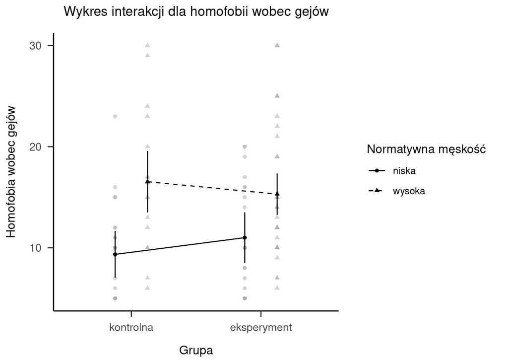

Rysunek 6.1: Wykres interakcji dla homofobii wobec gejów

Tabela 6.2:

*Wyniki analizy wariancji homofobii wobec gejów*

| Effect | $\hat{\eta}^2_G$ | 90% CI | $F$ | $\mathit{df}$ | $\mathit{df}_{\mathrm{res}}$ | $p$ |
| --- | --- | --- | --- | --- | --- | --- |
| Grupa | 0,018 | [0,000, 0,087] | 1.73 | 1 | 92 | .192 |
| NM grupa | 0,176 | [0,073, 0,291] | 19.66 | 1 | 92 | < .001 |
| Grupa $\times$ NM grupa | 0,014 | [0,000, 0,078] | 1.31 | 1 | 92 | .255 |

Tabela 6.3:

*Testy post-hoc dla homofobii wobec gejów*

| Grupa 1 | Grupa 2 | *t*(92) | *p* |
| --- | --- | --- | --- |
| gr. kontrolna, wysoka | gr. eksperymentalna, wysoka | 0.667 | 0.909 |
| gr. kontrolna, niska | gr. kontrolna, wysoka | -3.742 | 0.002 |
| gr. kontrolna, niska | gr. eksperymentalna, wysoka | -3.835 | 0.001 |
| gr. kontrolna, niska | gr. eksperymentalna, niska | -0.964 | 0.770 |
| gr. eksperymentalna, niska | gr. kontrolna, wysoka | -2.790 | 0.032 |
| gr. eksperymentalna, niska | gr. eksperymentalna, wysoka | -2.639 | 0.047 |

```r
# test homogeniczności rozkładów
levene_HF_geje
```

```
## # A tibble: 1 × 4
##     df1   df2 statistic     p
##   <int> <int>     <dbl> <dbl>
## 1     3    92      1.60 0.195
```

```r
# ANOVA
Anova(HF_geje_lm)
```

```
## Anova Table (Type II tests)
##
## Response: HF_geje
##                Sum Sq Df F value   Pr(>F)
## grupa             2.2  1  0.0632   0.8021
## NM_grupa        689.8  1 19.6557 2.56e-05 ***
## grupa:NM_grupa   46.0  1  1.3104   0.2553
## Residuals      3228.6 92
## ---
## Signif. codes:  0 '***' 0.001 '**' 0.01 '*' 0.05 '.' 0.1 ' ' 1
```

```r
# średnie
M_HF_geje
```

```
## Estimated Marginal Means
##
## grupa       | NM_grupa |  Mean |   SE |         95% CI
## ------------------------------------------------------
## kontrolna   |    niska |  9.35 | 1.16 | [ 7.04, 11.65]
## eksperyment |    niska | 11.00 | 1.26 | [ 8.49, 13.51]
## kontrolna   |   wysoka | 16.53 | 1.53 | [13.50, 19.57]
## eksperyment |   wysoka | 15.30 | 1.03 | [13.25, 17.35]
##
## Marginal means estimated at grupa, NM_grupa
```

## 6.3 Homofobia wobec lesbijek

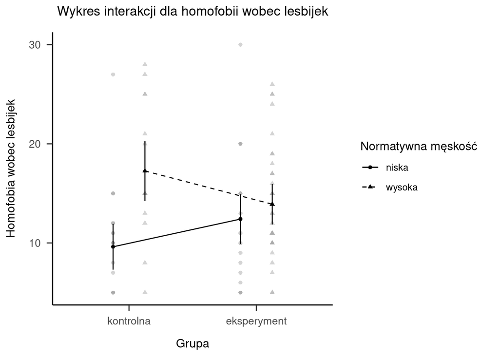

Rysunek 6.2: Wykres interakcji dla homofobii wobec lesbijek

Tabela 6.4:

*Wyniki analizy wariancji homofobii wobec lesbijek*

| Effect | $\hat{\eta}^2_G$ | 90% CI | $F$ | $\mathit{df}$ | $\mathit{df}_{\mathrm{res}}$ | $p$ |
| --- | --- | --- | --- | --- | --- | --- |
| Grupa | 0,006 | [0,000, 0,058] | 0.54 | 1 | 92 | .465 |
| NM grupa | 0,105 | [0,027, 0,212] | 10.81 | 1 | 92 | .001 |
| Grupa $\times$ NM grupa | 0,061 | [0,006, 0,155] | 5.99 | 1 | 92 | .016 |

Przeprowadzono drugą dwuczynnikową niezależną analizę wariancji celem sprawdzenia wpływu zagrożenia męskości i normatywnej męskości na homofobię wobec lesbijek. Wyniki przedstawiono w tabeli 6.4. Analiza efektów prostych względem zagrożenia męskości pozwoliła wykazać istnienie istotnej statystycznie różnicy między grupami w warunku braku zagrożenia męskości ($F(1, 92) = 15.94$, $p < .001$), która zanika w warunku zagrożenia męskości (($F(1, 92) = 0.85$, $p = .359$). Jednocześnie różnica w obrębie grupy o niskiej normatywnej męskości między warunkiem braku zagrożenia męskości ($\hat M = 9.62, SE = 1.16$) a warunkiem zagrożenia męskości ($\hat M = 12.41, SE = 1.26$) okazała się nieistotna statystycznie ($F(1, 92) = 2.66$, $p = .106$). Podobnie różnica w obrębie grupy o wysokiej normatywnej męskości między warunkiem braku zagrożenia męskości ($\hat M = 17.27, SE = 1.53$) a warunkiem zagrożenia męskości ($\hat M = 13.91, SE = 1.03$) nie osiągnęła progu istotności statystycznej ($F(1, 92) = 3.33$, $p = .071$), niemniej przyjęła wartość bliską wartości odcięcia. Wyłaniający się z danych malejący trend w grupie o wysokiej normatywnej męskości i rosnący trend w grupie o niskiej normatywnej męskości wymaga dalszych badań na większej próbie.

```r
# test homogeniczności rozkładów
levene_HF_lesbijki
```

```
## # A tibble: 1 × 4
##     df1   df2 statistic     p
##   <int> <int>     <dbl> <dbl>
## 1     3    92     0.849 0.470
```

```r
# ANOVA
Anova(HF_lesbijki_lm)
```

```
## Anova Table (Type II tests)
##
## Response: HF_lesbijki
##                Sum Sq Df F value   Pr(>F)
## grupa             0.1  1  0.0023 0.961937
## NM_grupa        377.4  1 10.8054 0.001434 **
## grupa:NM_grupa  209.2  1  5.9894 0.016290 *
## Residuals      3213.1 92
## ---
## Signif. codes:  0 '***' 0.001 '**' 0.01 '*' 0.05 '.' 0.1 ' ' 1
```

```r
# średnie
M_HF_lesbijki
```

```
## Estimated Marginal Means
##
## grupa       | NM_grupa |  Mean |   SE |         95% CI
## ------------------------------------------------------
## kontrolna   |    niska |  9.62 | 1.16 | [ 7.31, 11.92]
## eksperyment |    niska | 12.41 | 1.26 | [ 9.91, 14.91]
## kontrolna   |   wysoka | 17.27 | 1.53 | [14.24, 20.30]
## eksperyment |   wysoka | 13.91 | 1.03 | [11.87, 15.95]
##
## Marginal means estimated at grupa, NM_grupa
```

```r
# analiza efektów prostych względem zagrożenia męskości
sea_HF_lesbijki_grupa
```

```
## grupa = kontrolna:
##  model term df1 df2 F.ratio p.value
##  NM_grupa     1  92  15.944  0.0001
##
## grupa = eksperyment:
##  model term df1 df2 F.ratio p.value
##  NM_grupa     1  92   0.850  0.3589
```

```r
# analiza efektów prostych względem normatywnej męskości
sea_HF_lesbijki_NM_grupa
```

```
## NM_grupa = niska:
##  model term df1 df2 F.ratio p.value
##  grupa        1  92   2.663  0.1061
##
## NM_grupa = wysoka:
##  model term df1 df2 F.ratio p.value
##  grupa        1  92   3.329  0.0713
```